# Data Analysation

Gaben van den Hoeven, Tom Ummenthun and Nick Somsen

## Loading the dataset

Als eerst moet het bestand in R worden ingelezen. Dit is gedaan met behulp van de library here, die de current working directory met `here()` ophaald, en vervolgens wordt dit samengeplakt met een opgegeven bestandsnaam. Van de data in het bestand is vervolgens een data frame gemaakt met `read.table()`. De identifiers voor de rijen (`row.names`) zijn de gennamen, die in kolom 1 van het bestand staan.

```r
library(here)
file_name = paste(here(), "RNA-Seq-counts.txt", sep = "/")
data_frame = read.table(file = file_name, sep = "\t", header = TRUE, row.names = 1)
```

De data frame ziet er als volgt uit (alleen de eerste 10 regels):

```
##         WCFS1.glc.1 WCFS1.glc.2 WCFS1.rib.1 WCFS1.rib.2 NC8.glc.1 NC8.glc.2 NC8.rib.1 NC8.rib.2
## lp_0001        8100        9599        8144        7000      7117      8278      7457      6980
## lp_0002       12679       15856       11539       11049     10815     14348     10552     10735
## lp_0004        1795        1946        1470        1607      1489      1407      1587      1699
## lp_0005        8538        8740        5699        7402      6497      8565      6581      8342
## lp_0009       56040       42130       31941       23500     61965     37353     20498     18188
## lp_0010      105615       90094       60086       52584    103873     91726     45530     44802
## lp_0011       68724       63725       37616       37478     63512     66621     31123     31592
## lp_0012        6956        7088        6693        7813      5982      6857      7613      8339
## lp_0013        3968        3834        3215        4480      3153      4021      3562      4994
## lp_0014        5029        4999        3983        4605      4206      4573      4658      5528
```

Om makkelijk met de count data te kunnen werken, wordt er van de data frame een DGEList object gemaakt. `DGEList()` is een functie van `edgeR`, die dus eerst nog geïmporteerd moet worden:

```r
library(edgeR)
```

Voor een DGEList moet de counts data (vanuit de dataset) en de groups worden opgegeven. De groups is een factor die de mogelijke condities van de samples aangeven (dus welke *L. plantarum* stam het is en of het een glucose of ribose voedingsbodem is). Het aanmaken van die groups gaat als volgt (je hoeft niet aan te geven welke de eerste is en welke de duplo met 1 of 2; dat gebeurt later automatisch):

```r
exp = c("WCFS1.glc","WCFS1.glc","WCFS1.rib","WCFS1.rib", "NC8.glc", "NC8.glc", "NC8.rib", "NC8.rib")
group = factor(exp)
```

Nu kan het DGEList object aangemaakt worden. Voor de `counts` parameter moeten de counts vanuit de dataframe geselecteerd worden. De `group` parameter is de eerder aangemaakte group factor.

```r
y <- DGEList(counts=data_frame[,1:8], group=group)
```

Het printen van de DGEList leverd het volgende resultaat:

```
## An object of class "DGEList"
## $counts
##         WCFS1.glc.1 WCFS1.glc.2 WCFS1.rib.1 WCFS1.rib.2 NC8.glc.1 NC8.glc.2 NC8.rib.1 NC8.rib.2
## lp_0001        8100        9599        8144        7000      7117      8278      7457      6980
## lp_0002       12679       15856       11539       11049     10815     14348     10552     10735
## lp_0004        1795        1946        1470        1607      1489      1407      1587      1699
## lp_0005        8538        8740        5699        7402      6497      8565      6581      8342
## lp_0009       56040       42130       31941       23500     61965     37353     20498     18188
## 2214 more rows ...
##
## $samples
##                 group lib.size norm.factors
## WCFS1.glc.1 WCFS1.glc 10153710            1
## WCFS1.glc.2 WCFS1.glc 10615392            1
## WCFS1.rib.1 WCFS1.rib  8959060            1
## WCFS1.rib.2 WCFS1.rib  9340139            1
## NC8.glc.1     NC8.glc  9821662            1
## NC8.glc.2     NC8.glc 10261922            1
## NC8.rib.1     NC8.rib  9951954            1
## NC8.rib.2     NC8.rib  9957519            1
```

## Normalize the data

Zodat de data met elkaar vergeleken kan worden, moet de data genormaliseerd worden. Hierdoor wordt bijvoorbeeld het effect van biologischefactoren die buiten je macht om de data beïnvloeden, geminimaliseerd.

Er zijn verschillende manieren om data te normaliseren. Eén van deze manieren is de Trimmed Mean Method (TMM). De TMM methode is een normalisatie methode waarbij het gemiddelde pas wordt berekend, nadat een bepaalde hoeveelheid van de laagste en hoogste waarden van de dataset zijn verwijderd. De hoeveelheid waarden die van beide kanten worden weggegooid kunnen absolute aantallen zijn of percentages, vaak dezelfde hoeveelheid voor beide kanten.

Nadat deze outliers van de dataset zijn verwijderd, wordt de trimmed mean bepaald aan de hand van een formule. De trimmed mean wordt gebruikt omdat het uitschieters niet mee neemt in de berekeningen, die anders de data op een negatieve manier zouden beïnvloeden. Bovendien wordt door het uitsluiten van de uitschieters een beter beeld van de werkelijkheid verkregen.

De trimmed mean, en andere metingen en waarden, geven een basis voor de vergelijking van de data.

In R kan de trimmed mean normalisatie methode worden uitgevoer met `calcNormFactors()`, een functie van de `edgeR` library:

```r
y <- calcNormFactors(y, method="TMM")
y
```

```
## An object of class "DGEList"
## $counts
##         WCFS1.glc.1 WCFS1.glc.2 WCFS1.rib.1 WCFS1.rib.2 NC8.glc.1 NC8.glc.2 NC8.rib.1 NC8.rib.2
## lp_0001        8100        9599        8144        7000      7117      8278      7457      6980
## lp_0002       12679       15856       11539       11049     10815     14348     10552     10735
## lp_0004        1795        1946        1470        1607      1489      1407      1587      1699
## lp_0005        8538        8740        5699        7402      6497      8565      6581      8342
## lp_0009       56040       42130       31941       23500     61965     37353     20498     18188
## 2214 more rows ...
##
## $samples
##                 group lib.size norm.factors
## WCFS1.glc.1 WCFS1.glc 10153710    0.9850714
## WCFS1.glc.2 WCFS1.glc 10615392    0.9830048
## WCFS1.rib.1 WCFS1.rib  8959060    0.9986438
## WCFS1.rib.2 WCFS1.rib  9340139    1.0375329
## NC8.glc.1     NC8.glc  9821662    0.9390775
## NC8.glc.2     NC8.glc 10261922    1.0155475
## NC8.rib.1     NC8.rib  9951954    0.9899344
## NC8.rib.2     NC8.rib  9957519    1.0557378
```

Wanneer de TMM methode als normalisatie methode wordt uitgevoerd, hoeft er niet meer gefilterd te worden op low reads.

Vervolgens wordt er een design matrix gemaakt, die data aan elkaar linkt. Een design matrix is “a matrix of values of explanatory variables of a set of objects. Each row represents an individual object, with the successive columns corresponding to the variables and their specific values for that object” [via https://en.wikipedia.org/wiki/Design_matrix]. In R kan er een design matrix worden gemaakt met de `model.matrix()` functie. Het object waarover de design matrix moet worden gemaakt wordt opgegeven als de eerste parameter. De data vanuit de data frame die gelinkt moet worden aan het object wordt met de `data` parameter opgegeven. De kolommen van de design matrix krijgen een naam met de `colnames()` functie.

```r
design <- model.matrix(~0+group, data=y$samples)
colnames(design) <- levels(y$samples$group)
```

De desing matrix ziet er als volgt uit:

```
##             NC8.glc NC8.rib WCFS1.glc WCFS1.rib
## WCFS1.glc.1       0       0         1         0
## WCFS1.glc.2       0       0         1         0
## WCFS1.rib.1       0       0         0         1
## WCFS1.rib.2       0       0         0         1
## NC8.glc.1         1       0         0         0
## NC8.glc.2         1       0         0         0
## NC8.rib.1         0       1         0         0
## NC8.rib.2         0       1         0         0
## attr(,"assign")
## [1] 1 1 1 1
## attr(,"contrasts")
## attr(,"contrasts")$group
## [1] "contr.treatment"
```

## Calculate the dispersion

Om de spreiding tussen de data te bepalen, moet de dispersie worden berekent.

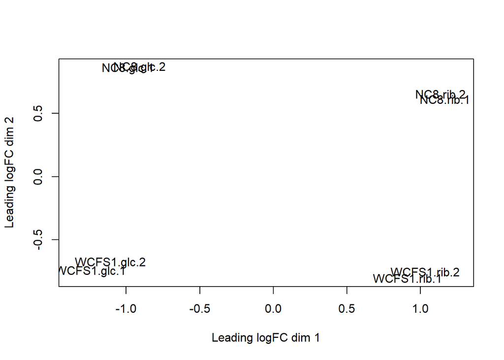

```r
y = estimateGLMCommonDisp(y,design)
y = estimateGLMTrendedDisp(y,design, method="power")
y = estimateGLMTagwiseDisp(y,design)

plotMDS(y)
```

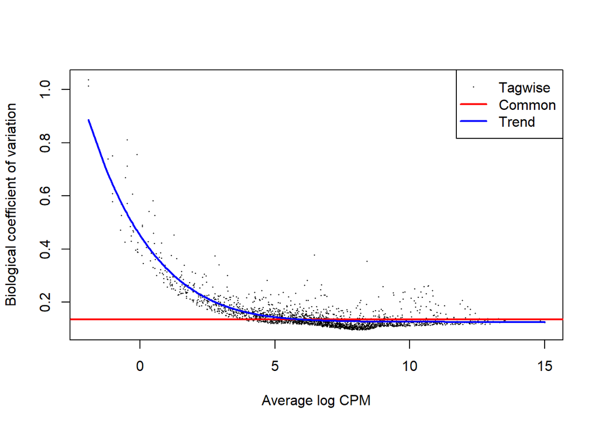

```r
plotBCV(y)
```

## Calculate Fold changes

```r
fit = glmFit(y, design)
mc = makeContrasts(exp.r=WCFS1.glc-WCFS1.rib, levels=design)
mc
```

```
##            Contrasts
## Levels      exp.r
##   NC8.glc       0
##   NC8.rib       0
##   WCFS1.glc     1
##   WCFS1.rib    -1
```

```r
fit = glmLRT(fit, contrast=mc)
fit
```

```
## An object of class "DGELRT"
## $coefficients
##           NC8.glc   NC8.rib WCFS1.glc WCFS1.rib
## lp_0001 -7.152383 -7.249621 -7.052922 -7.110752
## lp_0002 -6.665030 -6.862661 -6.575871 -6.713063
## lp_0004 -8.817011 -8.731840 -8.606074 -8.709080
## lp_0005 -7.178016 -7.221377 -7.075459 -7.263801
## lp_0009 -5.268519 -6.263070 -5.334961 -5.809969
## 2214 more rows ...
##
## $fitted.values
##         WCFS1.glc.1 WCFS1.glc.2 WCFS1.rib.1 WCFS1.rib.2 NC8.glc.1 NC8.glc.2 NC8.rib.1 NC8.rib.2
## lp_0001    8650.498    9024.857    7303.078    7910.211  7221.689  8159.834  6999.008  7468.424
## lp_0002   13938.764   14541.977   10869.822   11773.472 11757.002 13284.313 10306.085 10997.303
## lp_0004    1830.173    1909.375    1476.844    1599.619  1366.691  1544.233  1589.610  1696.224
## lp_0005    8457.716    8823.732    6266.664    6787.636  7038.926  7953.328  7199.515  7682.379
## lp_0009   48211.116   50297.499   26818.456   29047.978 47511.276 53683.303 18771.334 20030.307
## 2214 more rows ...
##
## $deviance
##  lp_0001  lp_0002  lp_0004  lp_0005  lp_0009
## 2.836642 2.509747 1.396544 2.831576 9.044387
## 2214 more elements ...
##
## $method
## [1] "oneway"
##
## $unshrunk.coefficients
##           NC8.glc   NC8.rib WCFS1.glc WCFS1.rib
## lp_0001 -7.152400 -7.249639 -7.052936 -7.110768
## lp_0002 -6.665039 -6.862673 -6.575880 -6.713073
## lp_0004 -8.817096 -8.731919 -8.606143 -8.709156
## lp_0005 -7.178033 -7.221394 -7.075474 -7.263819
## lp_0009 -5.268521 -6.263077 -5.334964 -5.809973
## 2214 more rows ...
##
## $df.residual
## [1] 4 4 4 4 4
## 2214 more elements ...
##
```

[output cut: 55 more lines]

```
## $table
##              logFC    logCPM        LR     PValue
## lp_0001 0.08343159  9.632701 0.2167445 0.64153174
## lp_0002 0.19792667 10.267411 1.2419861 0.26508862
## lp_0004 0.14860610  7.362873 0.8912638 0.34513505
## lp_0005 0.27172030  9.570237 2.3158990 0.12805724
## lp_0009 0.68529162 11.860592 5.9641810 0.01459938
## 2214 more rows ...
##
## $comparison
## [1] "1*WCFS1.glc -1*WCFS1.rib"
##
## $df.test
## [1] 1 1 1 1 1
## 2214 more elements ...
```

```r
topTags(fit)
```

```
## Coefficient:  1*WCFS1.glc -1*WCFS1.rib
##             logFC    logCPM        LR        PValue           FDR
## lp_3658 -8.133287 12.115754 1094.1988 6.022061e-240 1.336295e-236
## lp_3660 -8.397818 11.386324  879.4421 2.890204e-193 3.206681e-190
## lp_3659 -8.140484 11.024045  866.2004 2.185818e-190 1.616777e-187
## lp_2154 -5.889597 10.206500  772.1069 6.261149e-170 3.473372e-167
## lp_2151 -5.971339 11.156879  755.4808 2.580356e-166 1.145162e-163
## lp_2152 -6.031283 11.033466  720.3204 1.140233e-158 4.216961e-156
## lp_2153 -5.913049 10.440918  700.0413 2.928976e-154 9.284853e-152
## lp_0371 -5.667218  8.972546  669.6151 1.211472e-147 3.360321e-145
## lp_0575  4.688806  9.926790  577.3386 1.422276e-127 3.506701e-125
## lp_2702 -7.076657 11.133050  546.2424 8.268428e-121 1.834764e-118
```

## Results

```r
testvalue = fit$table[,4]
testvalue
```

[output not shown]

[output cut: 355 more lines]